# Name Length

2025-02-11

# Plot of Average Name Length in Male and Female

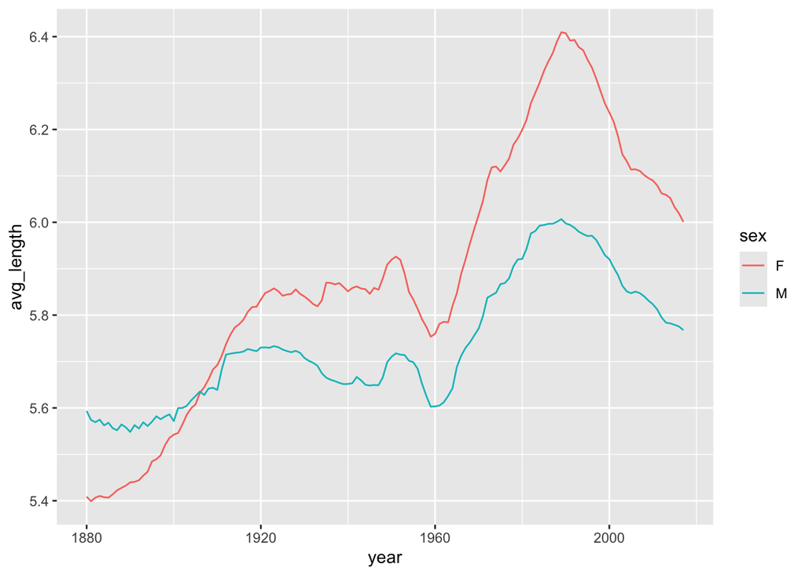

# Check Stationary: ACF Analysis & Differencing

Autocorrelation Function (ACF) helps us analyze the dependency of a time series on its past values. If a time series exhibits high autocorrelation at many lags, it suggests the presence of trends, making it non-stationary. Differencing is a method used to remove trends and achieve stationarity, which is essential for effective time series modeling.

The first-order difference operator is given by [1]:

$$Z_n = \Delta y_n = y_n - y_{n-1}$$

This transformation helps eliminate linear trends, making the series more stationary.

The second-order difference formula is given by [2]:

$$Z_n = \Delta^2 y_n = (y_n - y_{n-1}) - (y_{n-1} - y_{n-2}) = y_n -
2y_{n-1} + y_{n-2}$$

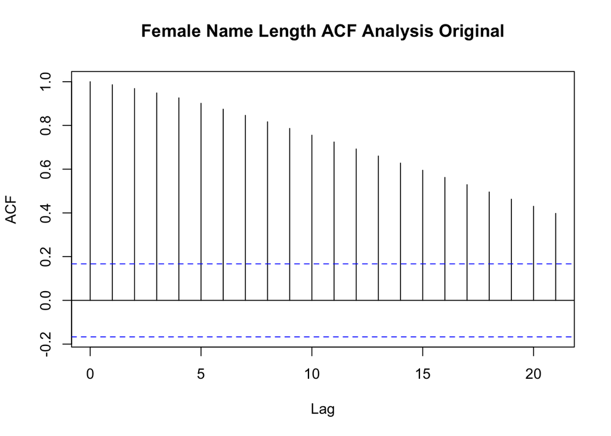

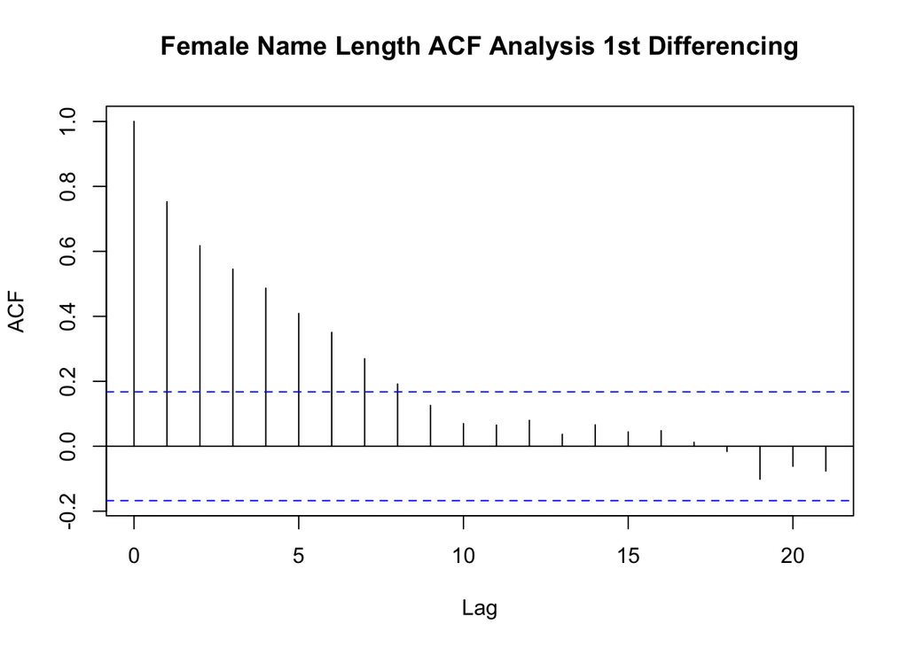

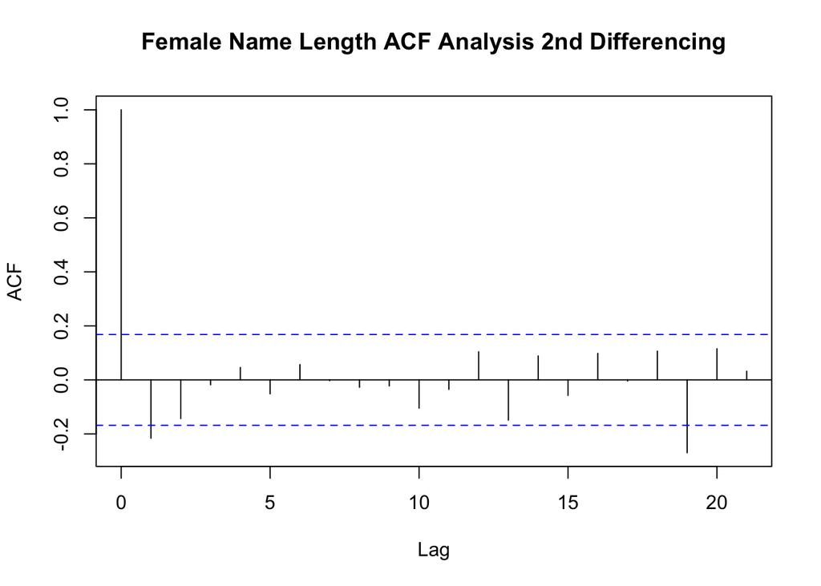

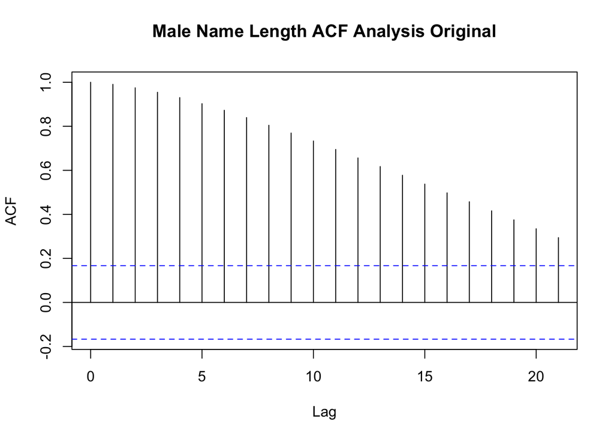

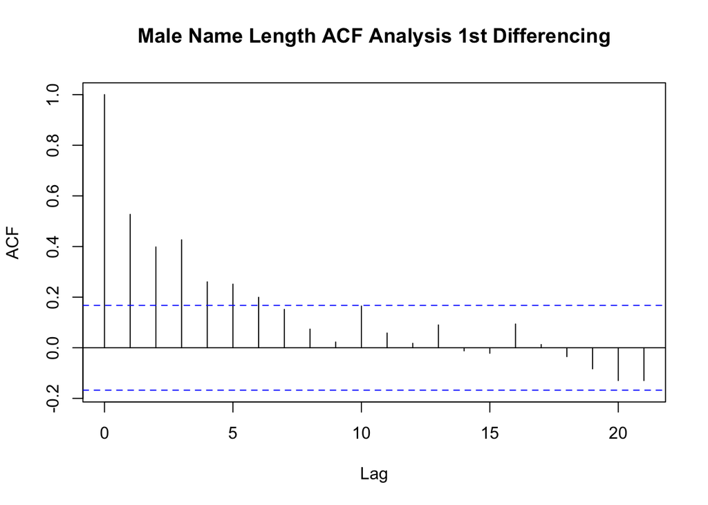

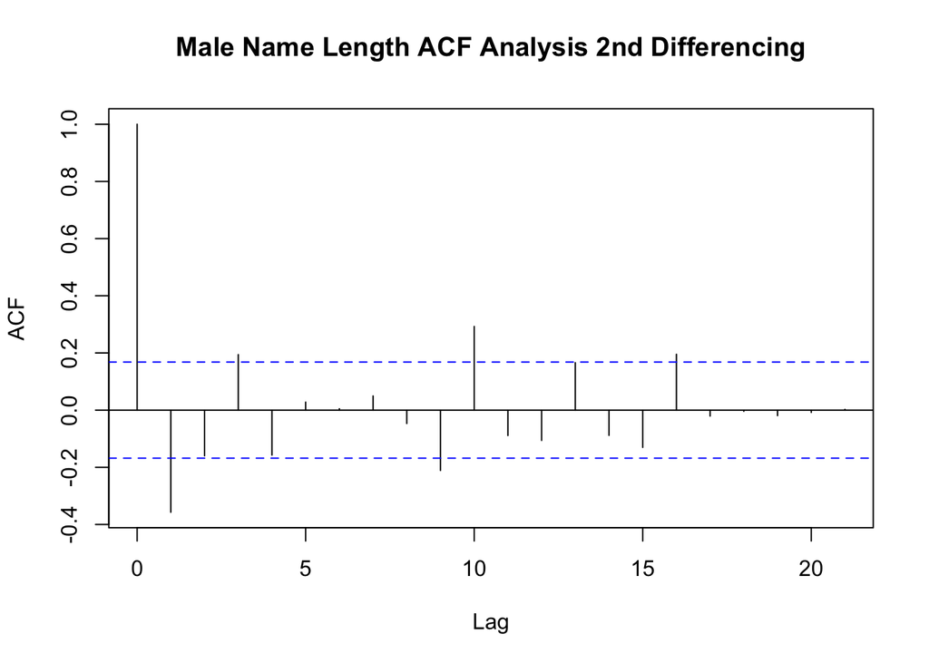

# Model Fitting and Selection by AIC

The Autoregressive Moving Average (ARMA) model is given by [3]:

$$Y_n = \phi_1 Y_{n-1} + \phi_2 Y_{n-2} + \dots + \phi_p Y_{n-p} +
\epsilon_n + \psi_1 \epsilon_{n-1} + \dots + \psi_q \epsilon_{n-q}$$

where $\epsilon_n$ is a white noise process. Using the **backshift operator**, this can be rewritten as [3]:

$$\phi(B) Y_n = \psi(B) \epsilon_n$$

To select the best model, we use Akaike’s Information Criterion (AIC), which is defined as [4]:

$$AIC = -2 \times \ell(\theta^*) + 2D$$

where $\ell(\theta^*)$ is the maximized log-likelihood, and $D$ is the number of parameters. We select the model with the lowest AIC value to balance goodness-of-fit and model complexity, avoiding overfitting.

# Apply `aic_table()` Function for Both Genders

# Display the AIC Tables

AIC Table for Female Names

|  | MA0 | MA1 | MA2 | MA3 | MA4 | MA5 |
| --- | --- | --- | --- | --- | --- | --- |
| AR0 | -813.07 | -821.57 | -822.88 | -820.93 | -819.00 | -817.79 |
| AR1 | -817.63 | -822.91 | -820.92 | -822.90 | -817.35 | -815.78 |
| AR2 | -821.15 | -820.92 | -823.10 | -822.09 | -817.85 | -819.72 |
| AR3 | -820.71 | -823.64 | -820.66 | -826.28 | -824.06 | -822.16 |
| AR4 | -818.75 | -821.98 | -823.94 | -821.94 | -819.96 | -824.09 |

AIC Table for Male Names

|  | MA0 | MA1 | MA2 | MA3 | MA4 | MA5 |
| --- | --- | --- | --- | --- | --- | --- |
| AR0 | -794.88 | -826.22 | -826.32 | -824.97 | -828.36 | -826.36 |
| AR1 | -811.50 | -826.09 | -826.98 | -825.04 | -828.12 | -827.35 |
| AR2 | -825.76 | -823.76 | -825.16 | -828.87 | -825.29 | -823.38 |
| AR3 | -823.76 | -830.07 | -829.91 | -827.99 | -827.37 | -828.40 |
| AR4 | -825.19 | -828.98 | -827.96 | -826.10 | -828.30 | -825.46 |

**Model Selection:**

- For female name lengths, we select ARMA(3,3) as it provides the best balance between model complexity and fit according to the AIC values.
- For male name lengths, we select ARMA(3,1) based on the lowest AIC score.

# Fit ARMA Models

```
##
## Call:
## arima(x = diff2_ts_female, order = c(3, 0, 3))
##
## Coefficients:
##          ar1      ar2     ar3      ma1     ma2      ma3  intercept
##       2.1120  -1.9233  0.7065  -2.4665  2.4659  -0.9992     -1e-04
## s.e.  0.0639   0.1030  0.0670   0.0424  0.0784   0.0453      1e-04
##
## sigma^2 estimated as 0.0001138:  log likelihood = 421.14,  aic = -826.28
```

```
##
## Call:
## arima(x = diff2_ts_male, order = c(3, 0, 1))
##
## Coefficients:
##          ar1     ar2     ar3      ma1  intercept
##       0.4116  0.0698  0.2374  -0.9999      0e+00
## s.e.  0.0845  0.0908  0.0841   0.0227      1e-04
##
## sigma^2 estimated as 0.0001172:  log likelihood = 421.04,  aic = -830.07
```

# Residual Diagnostics

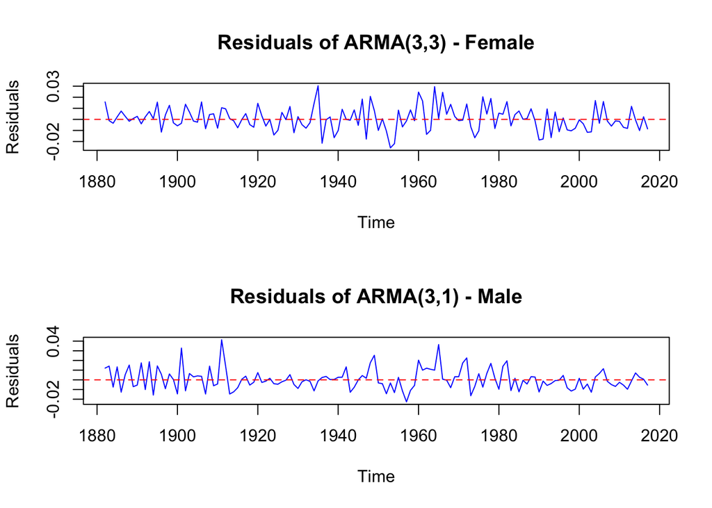

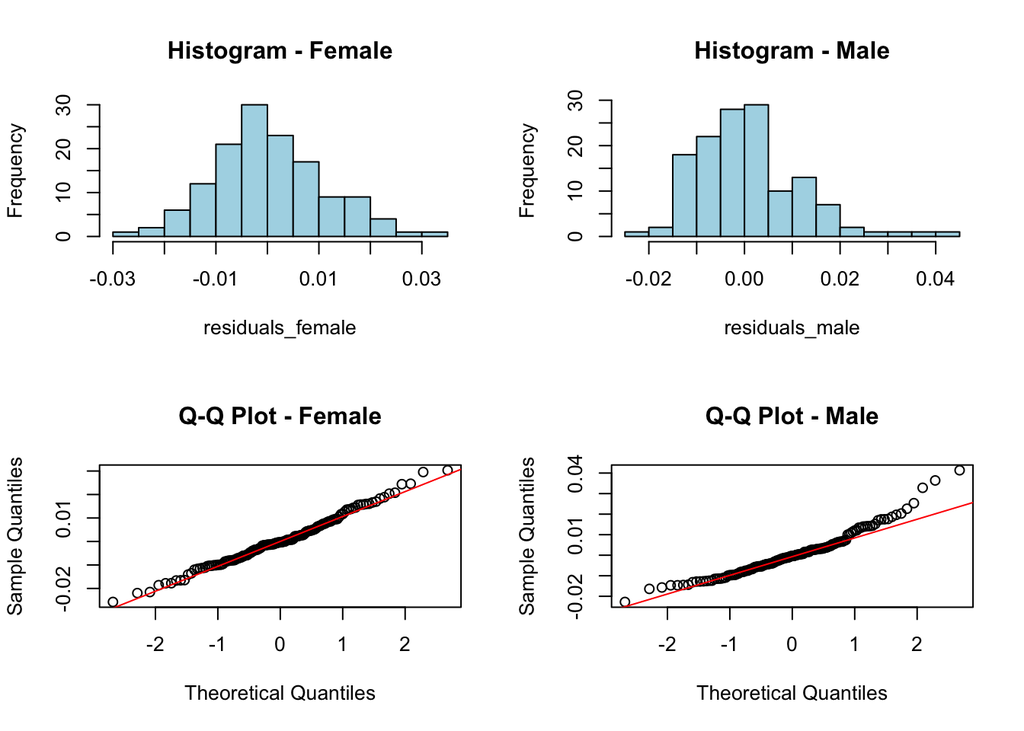

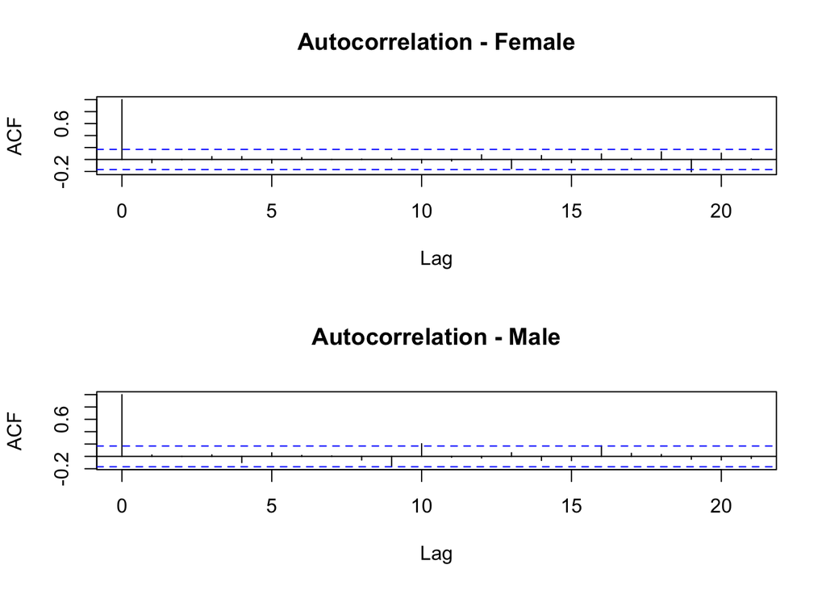

```
##
##  Box-Ljung test
##
## data:  residuals_female
## X-squared = 2.3537, df = 10, p-value = 0.9928
```

```
##
##  Box-Ljung test
##
## data:  residuals_male
## X-squared = 12.52, df = 10, p-value = 0.2518
```

# Compute & Plot Inverse ARMA Roots(Diagnosis of causality, invertibility, stationarity)

- The ARMA model is causal if all AR polynomial roots satisfy $\phi(x) = 1 - \phi_1 x - \phi_2 x^2 - \dots - \phi_p x^p$ and are outside the unit circle.
- The ARMA model is invertible if all MA polynomial roots satisfy $\psi(x) = 1 + \psi_1 x + \psi_2 x^2 + \dots + \psi_q x^q$ and are outside the unit circle.
- We use the `polyroot()` function to compute and check these roots [5].

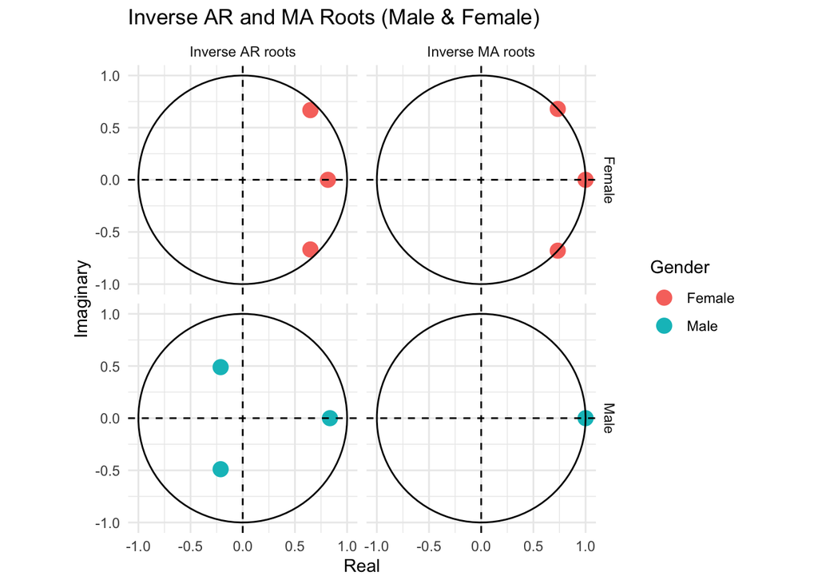

# References

[1] Stationarity, white noise, and some basic time series models lecture slides Ch03 p.25. https://ionides.github.io/531w25/03/slides-annotated.pdf

[2] Calculate the second order differencing of time series. https://www.philippe-fournier-viger.com/spmf/TimeSeriesSecondOrderDifferencing.php#:~:text=Calculating%20the%20second%20order%20differencing,Y_(i%2D2).

[3] Linear time series models and the algebra of ARMA models lecture slides Ch04 p.13 https://ionides.github.io/531w25/04/slides-annotated.pdf.

[4] Parameter estimation and model identification for ARMA models lecture slides Ch05 p.21. https://ionides.github.io/531w25/05/slides-annotated.pdf

[5] Linear time series models and the algebra of ARMA models lecture slides Ch04 p.17 https://ionides.github.io/531w25/04/slides-annotated.pdf.

[6] https://ionides.github.io/531w24/midterm_project/project02/blinded.html